# Re-pilot report: inference for the Youden curve under multiple imputation

A review document: the re-pilot of the re-scoped proposal, its results, the draft spec, and the decisions log

Published

October 29, 2026

# Summary

**Scope.** This document reports the re-pilot[^1] of the re-scoped proposal (`proposal.md`, section 12, “Pool first or optimize first? Cutoffs from multiply imputed biomarker data”, re-scoped after the first pilot failed): what the re-scoped idea is, how the re-pilot was run, what it found, the full draft project spec, and the decisions made along the way. It was built from `project-spec.md`, `decisions.md`, the pre-registration `preregistration.md` with its amendment, and the saved results in `pilot-b/results/`; the NHANES description and the first pilot’s base cell are read, read-only, from `pilot/results/`. Every number in the text and figures is computed from those files when the document renders.

**Status.** In `STATUS.md` the re-pilot is marked `piloted-close-call`[^2], by the pre-registered rule, for a spec that applies to the re-scoped proposal (a conditional draft[^3]). The problem is clear and large, and the bootstrap-then-impute correction removes 85% of the index’s optimism in the base cell. The one failed criterion is the bootstrap band’s coverage with predictive mean matching, 0.910 (MCSE 0.013), 0.8 MCSE below the 0.92 limit. The reading that passes: the band covers 0.91 to 0.94 of replicates across all cells and passes with the correctly specified imputation. The reading that fails: the band sits below 0.95 even without imputation, the correction overshoots at 60% missing, and the near-optimal sets are wide (decisions log, D1).

| Pilot question | Answer | Key evidence |
| --- | --- | --- |
| 1. Does the problem exist? | yes | optimism of the reported index 0.0261 (MCSE 0.0017); pointwise intervals cover the whole curve in 0.414 of replicates |
| 2. Large enough at realistic n? | yes | optimism 0.0261 at 40% and 0.0301 at 60% missing, against 0.01 |
| 3. Obvious fix? | partly; a close call | corrected bias 0.0038 (MCSE 0.0019); bootstrap band coverage 0.910 (PMM) and 0.944 (normal) against 0.92 to 0.98; near-optimal set contains c* in 1.000 |

**What needs your decision** (details in Action items and limitations): the close call, read both ways in the decisions log (D1); the re-scope and the re-pilot’s pass rule, which were pre-registered without a stop at your instruction (D2); the width of the near-optimal sets, which the pass rule did not judge; the two yellow `[TO CONFIRM]` items in the spec; and two citations not in the Zotero library.

# The idea

## In plain language

A clinic that picks a cutoff for a blood test from its own data reports how well the cutoff works, as sensitivity plus specificity minus one (the Youden index[^4]). That number is optimistic. The cutoff was chosen because the data happened to favour it, so on new patients it does a little worse than reported. With 250 patients per group the first pilot found the overstatement to be about two points of the index, whether or not the missing test values had been filled in by multiple imputation[^5]. The study also reports no margin of error, because no method gives one when values were imputed.

This re-pilot tests three repairs on simulated data where the truth is known. The first is a margin of error for the whole accuracy curve: a band that should contain the true curve at every cutoff in 95 out of 100 studies (a simultaneous band). The second follows from it: the set of cutoffs the band cannot tell apart from the best one, for example “anything from 0.8 to 1.3” rather than “1.06”. The third is a corrected index: the data are resampled, re-imputed, and re-analysed 200 times to measure how much choosing a cutoff flatters it (a bootstrap[^6] estimate of the optimism), and that amount is subtracted.

## Potential impact

No published method gives a band for the accuracy curve, a set of near-optimal thresholds, or an optimism-corrected index when the marker has been multiply imputed. Complete-data methods exist for intervals of the index and the cutoff (Bantis, Nakas, and Reiser 2019) and for the joint uncertainty of sensitivity and specificity at an estimated cutoff (Bantis, Nakas, and Reiser 2014). For imputed data, Long, Zhang, and Hsu (2011) pooled the curves and reported a threshold with no uncertainty, and the general results on combining the bootstrap with imputation (Bartlett and Hughes 2020; von Hippel and Bartlett 2021) have not been applied to a curve or its maximum. The cutoff itself is a cube-root estimator for which the standard bootstrap is inconsistent (Cattaneo, Jansson, and Nagasawa 2020), so whether a bootstrap correction of its index works is not known.

The problem is a reporting gap. Studies that impute a missing marker and publish an optimal cutoff report an index that overstates the cutoff’s accuracy and no measure of how well the cutoff is determined, because the tools they would need exist only for complete data. Many authors do not report the precision of their cutpoints even with complete data (Thiele and Hirschfeld 2023).

If the band covers and the correction works, an analyst can report three things in place of one number: the pooled curve with its band, the range of cutoffs that are statistically as good as the best, and an index that estimates the accuracy the chosen cutoff will deliver. That changes how diagnostic-accuracy and prediction studies with imputed markers present a cutoff, in laboratory medicine and epidemiology in particular, where the cotinine application below sits. The re-pilot shows the size of what is at stake: the reported index overstates the chosen cutoff’s accuracy by 0.026 in the base cell (Figure 6), pointwise intervals read across thresholds cover the whole curve in only 41% of replicates (Figure 4), and the corrected index and the bootstrap band are the repairs whose performance Table 4 reports cell by cell.

## Application: the study behind the data

### The study

The National Health and Nutrition Examination Survey[^7] (NHANES) samples the noninstitutionalized United States population in two-year cycles, interviews each participant, and examines a subsample in a mobile examination center, where blood is drawn. Serum cotinine[^8], the main metabolite of nicotine, was measured in examined participants aged 3 and over in the cycles 2013-2014, 2015-2016, and 2017-2018, with the same laboratory method (isotope-dilution liquid chromatography with tandem mass spectrometry) and the same lower limit of detection, 0.015 ng/mL; values below it are set to the limit divided by the square root of two (documentation files `COT_H`, `COT_I`, and `COT_J`, read 2026-10-28). Adults answer a smoking questionnaire (`SMQ`). The files are public at wwwn.cdc.gov/Nchs/Data/Nhanes/Public/, with no login.

Two studies used these survey data to choose a cotinine cutoff for current smoking. Benowitz, Bernert, Caraballo, Holiday, and Wang (2009), *American Journal of Epidemiology* 169(2):236-48 (doi:10.1093/aje/kwn301), used the cycles 1999 to 2004 and found that optimal cutoffs differed by race/ethnicity, 5.92 ng/mL for non-Hispanic Black, 4.85 for non-Hispanic White, and 0.84 for Mexican American adults. Tompkins, Beltran, and Bedno (2019), *Biomarkers in Medicine* 13(12):1025-1033 (doi:10.2217/bmm-2019-0027), used the cycles 2009 to 2014 and found an adult cutoff of 3.63 ng/mL that differed by sex and race/ethnicity. In the three cycles used here, 17,948 adults answered the smoking question, 3,353 of them current smokers[^9], and cotinine is missing for 9.6% of them (Table 1).

Table 1: Adults aged 18 and over with an answer to the smoking question, by NHANES cycle: current smokers, nonsmokers, participants not examined, participants with serum cotinine missing (of whom some were examined), values below the limit of detection, and the share missing. Computed from the downloaded NHANES files by pilot/nhanes.R (../pilot/results/nhanes_summary.rds, read-only).

|  | Cycle | Adults | Smokers | Nonsmokers | Not examined | Cotinine missing | Missing, examined | Below detection | Share missing |
| --- | --- | --- | --- | --- | --- | --- | --- | --- | --- |
| 2013-2014 | 2013-2014 | 6,111 | 1,232 | 4,879 | 189 | 471 | 282 | 1,759 | 7.7% |
| 2015-2016 | 2015-2016 | 5,981 | 1,100 | 4,881 | 256 | 586 | 330 | 1,794 | 9.8% |
| 2017-2018 | 2017-2018 | 5,856 | 1,021 | 4,835 | 323 | 658 | 335 | 1,783 | 11.2% |
| 1 | All three | 17,948 | 3,353 | 14,595 | 768 | 1,715 | 947 | 5,336 | 9.6% |

### Why the Youden index

A cotinine cutoff classifies a participant as a smoker when the measured value exceeds it, and the Youden index of a cutoff, sensitivity plus specificity minus one, is the share of smokers called smokers minus the share of nonsmokers called smokers. Both cotinine studies chose the cutoff that maximizes it. The estimand is the maximizer of the population Youden curve and the curve’s maximum; the question here is how to estimate both, with their uncertainty, when some cotinine values are missing and imputed. The proposed analysis imposes missingness at random on the adults with observed cotinine, so that the full-data cutoff is the benchmark, imputes, and compares the two pooling orders, overall and by race/ethnicity.

### Did the original study compute it?

Partly. Both studies estimated the optimal cutoff from receiver operating characteristic curves on participants with observed cotinine, and Benowitz et al. estimated it within race/ethnicity groups. Neither study imputed the missing cotinine values, and neither reported the uncertainty of its cutoff in the passages read for this project. The question here is new: how the cutoff, its index, and their uncertainty should be pooled once missing values are imputed, and whether the stratum-specific cutoff or the cutoff that is optimal for the population as a whole is the target within each race/ethnicity group.

## In symbols

Each group’s marker distribution ($F_0$, $F_1$), the Youden curve ($J(c)$), its maximizer and maximum ($c^*$, $J^*$), the curve of each of $L$ completed datasets ($\hat J_l$), their average ($\bar J$), the chosen cutoff ($\hat c$), the reported index ($A$), its optimism, a band with limits $\ell(c)$ and $u(c)$ over a grid of thresholds, and the near-optimal set ($S$) are related by

$$\begin{aligned}
J(c) &= F_0(c) - F_1(c), \qquad c^* = \arg\max_c J(c), \qquad J^* = J(c^*) \\
\bar J(c) &= \frac{1}{L}\sum_{l=1}^{L} \hat J_l(c), \qquad \hat c = \arg\max_c \bar J(c), \qquad A = \max_c \bar J(c) \\
\text{optimism} &= A - J(\hat c) \\
\text{band} &: \ \ell(c_k) \le J(c_k) \le u(c_k) \ \text{for all } k \text{ with probability } 0.95 \\
S &= \{c_k : u(c_k) \ge \max_j \ell(c_j)\}.
\end{aligned}$$

| Symbol | Meaning |
| --- | --- |
| $X$, $D$, $Z$ | the marker, the disease status (0 or 1), the auxiliary variable that predicts the marker |
| $J(c)$, $c^*$, $J^*$ | the Youden curve, its maximizer, its maximum |
| $L$, $\hat J_l$, $\bar J$ | number of imputations, curve of completed dataset $l$, their average |
| $\hat c$, $A$ | the chosen cutoff and the reported index, the maximizer and maximum of $\bar J$ |
| $c_1, \dots, c_K$ | the grid of $K = 41$ thresholds between the 10% and 90% quantiles of the observed marker |
| $\ell$, $u$ | the band’s lower and upper limits on the grid |
| $S$ | the near-optimal set: grid thresholds whose upper limit reaches the highest lower limit |
| $R_B$, $M$ | bootstrap resamples (200) and imputations per resample (2) |

The target is the curve $J$ over the grid, the threshold $c^*$, and the accuracy $J(\hat c)$ of the threshold actually chosen. What can be computed is $\bar J$, a band around it, and a corrected index. Two results make the set useful. If the band covers $J$ at every grid point, then $u(c^*) \ge J^* \ge J(c_j) \ge \ell(c_j)$ for every $j$, so $c^*$ is in $S$: the set inherits the band’s coverage. And the optimism is positive in expectation, because $A \ge \bar J(c^*)$ and $\bar J(c^*)$ is centered near $J^*$. The corrected index subtracts the bootstrap average of $\bar J_b(\hat c_b) - \bar J(\hat c_b)$, how much each resample’s chosen cutoff flatters the resample relative to the original data.

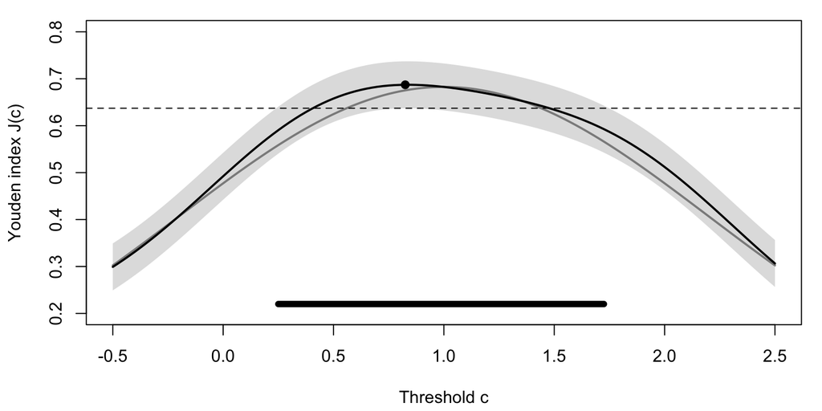

Figure 1: The idea, on made-up numbers (an illustration, not re-pilot output). A true Youden curve (grey), an estimated curve (black) whose maximum (dot) sits above the true curve at the chosen cutoff, and a band (shaded) around the estimate. The dashed line is the band’s highest lower limit; every threshold whose upper limit reaches it belongs to the near-optimal set (the bar under the curve).

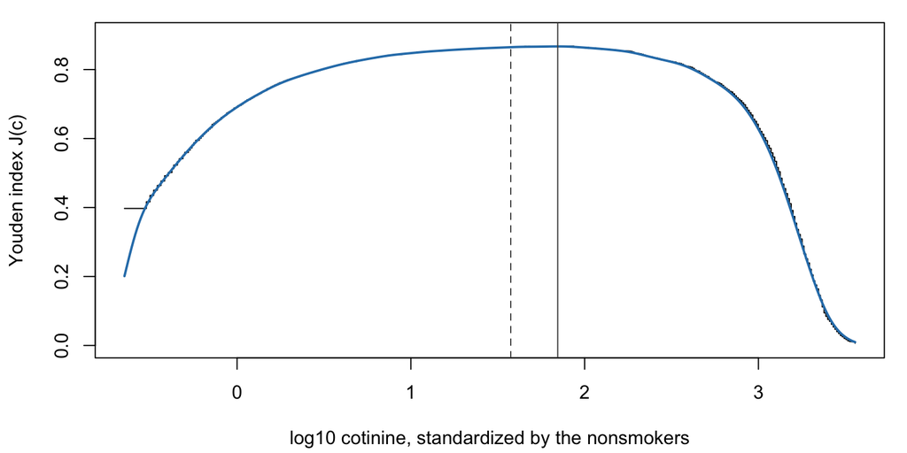

Figure 2: The real data: the full-data Youden curve of log serum cotinine among NHANES adults (2013 to 2018, participants with cotinine observed), current smokers against everyone else, on the scale used in the simulation (log cotinine standardized by the nonsmokers’ mean and standard deviation). Black: the empirical curve; blue: the Gaussian-kernel curve. The solid vertical line is the maximizer of the kernel curve; the dashed line is the adult cutoff of 3.63 ng/mL of Tompkins, Beltran, and Bedno (2019). From ../pilot/results/nhanes_summary.rds, read-only.

The full-data curve peaks at 7.35 ng/mL with an index of 0.868 (empirical curve); at the published adult cutoff of 3.63 ng/mL the empirical index is 0.865, lower by 0.003 for a cutoff half as large. The curve is flat over that range, which is the situation in which a near-optimal set is wide and a single cutoff says little. On the standardized scale its curvature at the peak is 0.229, between the flat (0.220) and the sharp (0.484) shapes of the simulation, and its maximum, 0.867, is above both. The cutoff here is higher than the published ones; the definitions differ, since everyone who is not a current cigarette smoker, including users of other tobacco products, counts as a nonsmoker here.

## Critiquing the model

Any model is a simplification, and the useful question is not whether it is true but where it bends and whether the bend matters for the question being asked. The model above was chosen so that the problem could be written as a formula and checked by simulation, and each simplification that made that possible is a place where real data may behave differently. The table lists the main ones. Work through it one row at a time. The first column names the feature and the symbols in the equations that carry it, so find them there first. Then decide in your own words how the feature could fail for real data before reading the second column, and finally read the third column for what should be done to check it. Several of these checks are natural first tasks for the project. Which of them the pilot examined, and which it left open, is for you to find when you read the Methods and Results that follow.

| Feature of the model | Why it may not be realistic | What should be done to check it |
| --- | --- | --- |
| Binormal marker, $X \mid D = d$ normal | Real markers are skewed or have a point mass (cotinine below the limit of detection), which changes how flat $J$ is near $c^*$ and so how wide $S$ is | Simulate from the real cotinine distribution by resampling the cohort and imposing missingness |
| The unknown parameters: $\delta$, $\sigma_1$, the auxiliary strength, the missingness coefficients | Two shapes and one auxiliary strength bracket a sharp and a flat peak; the band’s width and the optimism depend on all of them | Estimate them from the NHANES cohort and place the real data on each gradient |
| One auxiliary and a correctly specified normal imputation model | Real imputation models carry several covariates and are misspecified; the normal engine is correct here only because $X$ and $Z$ are jointly normal within groups | Add an arm with several auxiliaries and one omitted from the imputation model |
| Missing at random, concentrated at high $Z$ | Missingness tied to the marker’s own value is not corrected by either engine; at high missing fractions the grid built from observed values stops short of the high thresholds | State the assumption; build the grid from imputed values or a fixed range and compare |
| The band’s normal law for $\bar J$ on the grid (Rubin’s-rules band) | The sup-t critical value assumes $\bar J$ is close to normal jointly over the grid; near $J$’s extremes and at small $n$ the binomial parts are skewed | Compare the Rubin’s-rules band’s coverage with the bootstrap band’s across $n$ |
| A bootstrap of 200 resamples with 2 imputations each | Few resamples make the 95% sup-t quantile noisy; two imputations per resample leave the variance split noisy | Vary $R_B$ and $M$ and measure the change in coverage and width |
| The bootstrap optimism correction for a cube-root estimator | The standard bootstrap does not reproduce the distribution of a cube-root estimator (Cattaneo, Jansson, and Nagasawa 2020), so the resamples’ optimism need not match the original’s | Compare the correction’s bias across $n$; try a subsampling version of the correction |
| Equal group sizes | Smokers are about one in five NHANES adults; the band’s width is driven by the smaller group | Add an unbalanced arm at fixed total size |

# Methods

## Design

The re-pilot simulates the first pilot’s binormal marker, missing at random through one auxiliary, at 250 per group, and applies the empirical estimator to 20 completed datasets. Every replicate builds three bands for the curve on a 41-point grid (the pointwise Rubin’s intervals read across the grid, a Rubin’s-rules sup-t band, and a bootstrap-then-impute sup-t band), derives a near-optimal set from each sup-t band, and computes the bootstrap-then-impute optimism correction of the index from the same 200 resamples. The 10 cells cross two peak shapes with no imputation (0% missing) and with 40% and 60% missing imputed by predictive mean matching[^10] or by Bayesian normal linear regression[^11], for 500 replicates per cell. The known-answer checks run the same code on cases with known answers.

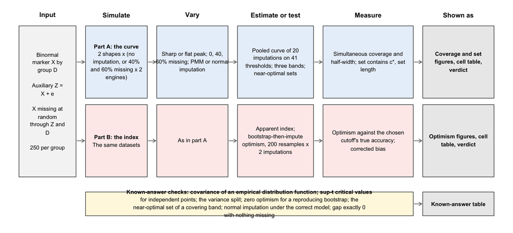

Figure 3: The design at a glance. Each row is one part of the re-pilot, read from left to right; both parts use the same simulated datasets. The bands’ coverage is shown in the coverage figure (Figure 4), the near-optimal sets in Figure 5, the optimism and its correction in Figure 6 and Figure 7, all cells in Table 4, and the verdict in Table 3; the checks are in Table 2.

Each figure and table in the Results traces back to one row of this diagram, and the row says what its points or entries represent.

| Part | What is simulated | Main factors | Replicates |
| --- | --- | --- | --- |
| A | $X \mid D{=}0 \sim N(0,1)$, $X \mid D{=}1 \sim N(\delta, \sigma_1^2)$; $Z = X + e$; $X$ missing with probability $\mathrm{expit}(\alpha_0 + Z + 0.5D)$; 20 imputations | shape, missing fraction, engine | 500 per cell, 10 cells |
| B | the same datasets, with 200 stratified bootstrap resamples, each imputed twice | as part A | the same |

The sharp shape has $\delta = 2$ and $\sigma_1 = 1$ ($c^* = 1.000$, $J^* = 0.6827$); the flat shape has $\delta = 1.5$ and $\sigma_1 = 2.5$ ($c^* = 1.355$, $J^* = 0.4354$). The Rubin’s-rules band combines the closed-form within-imputation covariance of the empirical curve over the grid with the between-imputation covariance of the 20 curves, and takes its critical value from 5,000 draws of the resulting normal law. The bootstrap-then-impute band resamples subjects within each group, imputes each resample twice, splits the pointwise variance into its sampling and imputation parts, and takes its critical value from the resamples’ largest standardized deviation. The base cell is the sharp shape with 40% missing and predictive mean matching; its normal twin uses normal imputation on the same design.

## Known-answer checks

Known-answer checks come before any result, because every later number is only as good as the simulation that produced it. Each check sets up a case where the correct answer is known from theory, runs the simulation code on it, and compares the two. Agreement says nothing about the scientific question or about real data. It says that the code does what the model says. Disagreement means stopping to look for a bug before reading anything else, and the same checks apply to any code you write for the project.

Read each row of the table in four steps: the setting that was simulated, the known answer for that setting, what the simulation gave, and whether the gap between the two is small compared with the Monte Carlo standard error (MCSE). The MCSE is how much a simulated result moves from run to run because only a finite number of replicates was used. A gap within about two MCSE is noise, and a gap of several MCSE is a problem.

Table 2: Known-answer checks, from results/known_answers.rds (written by pilot.R before the run, the same checks the test suite asserts) and, for the last rows, from results/cell_summaries.rds (the re-pilot’s null cells, where nothing is imputed).

| Check | Setting | Known answer | Simulation gave | How to read it |
| --- | --- | --- | --- | --- |
| Covariance of an empirical distribution function | N(0, 1), n = 100, a = -0.5, b = 0.5, 4,000 samples | (F(a) - F(a) F(b)) / n | 0.00088719 (MCSE 3.6e-05) | 1.8 MCSE from the known value, so the gap is noise. Judged at 3 MCSE, the re-pilot’s rule. |
| Covariance formula in code | YoudenCurveCov() with F1 = 0 | (F(a) - F(a) F(b)) / n | 0.000951954 | 0 from the known value, against a tolerance of 1e-15, so the check passes. |
| Sup-t critical value | 41 independent coordinates | qnorm((1 + 0.95^(1/41)) / 2) | 3.22482 | 0.002333 from the known value, against a tolerance of 0.02, so the check passes. |
| Sup-t critical value | one coordinate | 1.96 | 1.96257 | 0.002602 from the known value, against a tolerance of 0.02, so the check passes. |
| Variance split | synthetic resamples, M = 2 | 0.0004 + 0.0009 / 20 | 0.000444169 | 8.311e-07 from the known value, against a tolerance of 2e-05, so the check passes. |
| Optimism of a reproducing bootstrap | every resample equal to the data | exactly 0 | 0 | 0 from the known value, against a tolerance of 0, so the check passes. |
| Near-optimal set | a band of half-width 0.01 around J | contains c* = 1 | 1 | 0 from the known value, against a tolerance of 0, so the check passes. |
| Normal imputation, conditional mean | group 0, 20,000 per group, 40% missing | imputed minus Z / 2 averages 0 | 0.0049043 (MCSE 0.011) | 0.4 MCSE from the known value, so the gap is noise. Judged at 3 MCSE, the re-pilot’s rule. |
| Normal imputation, conditional variance | group 0, 20,000 per group, 40% missing | variance of imputed minus Z / 2 is 0.5 | 0.50715 (MCSE 0.011) | 0.6 MCSE from the known value, so the gap is noise. Judged at 3 MCSE, the re-pilot’s rule. |
| Pooling-order gap with nothing missing | both null cells | exactly 0 in every replicate | 0 nonzero of 1000 | No replicate has a nonzero gap, so the check passes. |

The rows without a standard error are exact identities or approximations judged against a tolerance. The bands’ coverage in the null cells is not a known-answer check, because their 95% level holds only approximately at 250 per group; it is reported with the results.

# Results

## How to read the outputs

Each output traces back to a row of the design diagram (the captions name the part where one applies). Read each in the same four steps. First, find its row in the diagram, which says what was simulated and what was varied. Second, work out what one point or one table entry is, usually one combination of the varied factors, averaged over replicates. Third, identify the reference value that would hold if nothing were wrong, shown as a dashed or grey line wherever possible. Fourth, look for where the results leave that reference, and for which settings they do. The outputs report three kinds of quantity.

- **Bias** is the average of an estimate minus its true value. When the truth is no difference, any average difference from 0 is a spurious difference created by the problem under study.
- **Level** is how often a test rejects when there is truly nothing to find. A correct test at 0.05 rejects 5% of the time, so a rate above 0.05 means too many false alarms.
- **Power** is how often a test rejects when there is a real effect. More is better, but only when the level is not inflated, because a test that rejects too often also looks powerful.

All rates and averages come from simulation, so each carries Monte Carlo error. That is why the figures show bars or a grey band, and why small differences should not be over-read.

This re-pilot has no test, so level and power do not arise; it reports four further quantities. A band’s simultaneous coverage is the share of replicates in which it contains the true curve at all 41 thresholds at once; a correct 95% band covers in 95% of replicates, and pointwise intervals read as a band cover less often, because each of 41 intervals has its own 5% chance to miss. A near-optimal set’s coverage is the share of replicates in which it contains the true optimal cutoff $c^*$, and its length is the width of the range of thresholds it spans. The optimism is the reported index minus the true accuracy of the cutoff it picked, averaged over replicates; zero is unbiased. The corrected index’s bias is the same difference after the bootstrap correction.

## The bands

**Figure guide (part A, every cell).** A correct simultaneous band covers the true curve in 95% of replicates, the solid line; the dashed lines are the pre-registered limits 0.92 and 0.98. One point is one cell’s coverage over 500 replicates: the bootstrap-then-impute band (black, with plus and minus two MCSE), the Rubin’s-rules sup-t band (blue triangles), and the pointwise intervals read as a band (orange crosses). Look for: whether the two sup-t bands cover near 0.95 in the cells without imputation; which engine and which missing fraction move them away; how far below the others the pointwise intervals sit.

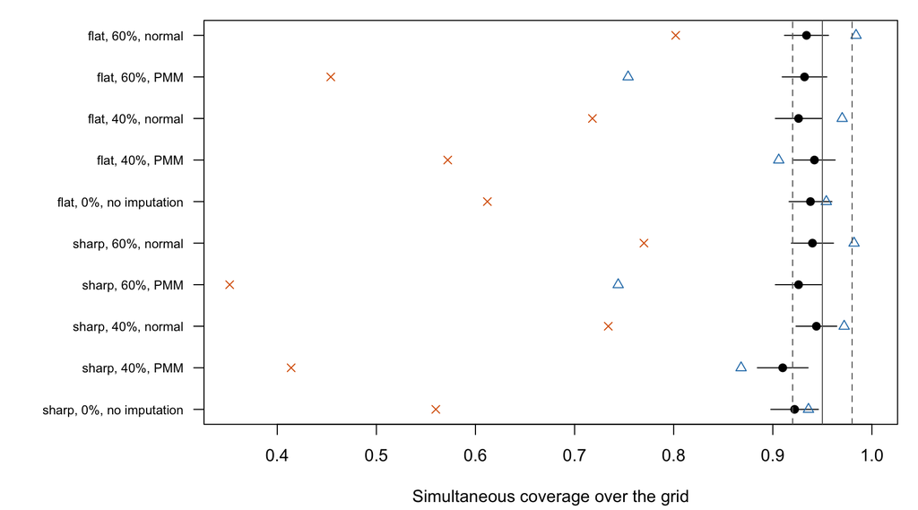

Figure 4: Part A: simultaneous coverage over the 41-threshold grid in every cell, for the bootstrap-then-impute band (black, plus and minus two MCSE), the Rubin’s-rules sup-t band (blue), and the pointwise Rubin’s intervals read as a band (orange). Solid line 0.95; dashed lines 0.92 and 0.98. From results/cell_summaries.rds.

**Figure guide (part A, the near-optimal sets).** If a band covers the true curve, its near-optimal set contains $c^*$, so the set’s coverage is at least the band’s; a useful set is also short. Left: one point is one cell’s share of replicates in which the set contains $c^*$, for the bootstrap-then-impute band (black) and the Rubin’s-rules band (blue), with the 0.92 threshold dashed. Right: the mean length of each set, in units of the marker (the grid spans about three units). Look for: whether set coverage tracks band coverage across cells; how wide the sets are for the sharp and the flat shape.

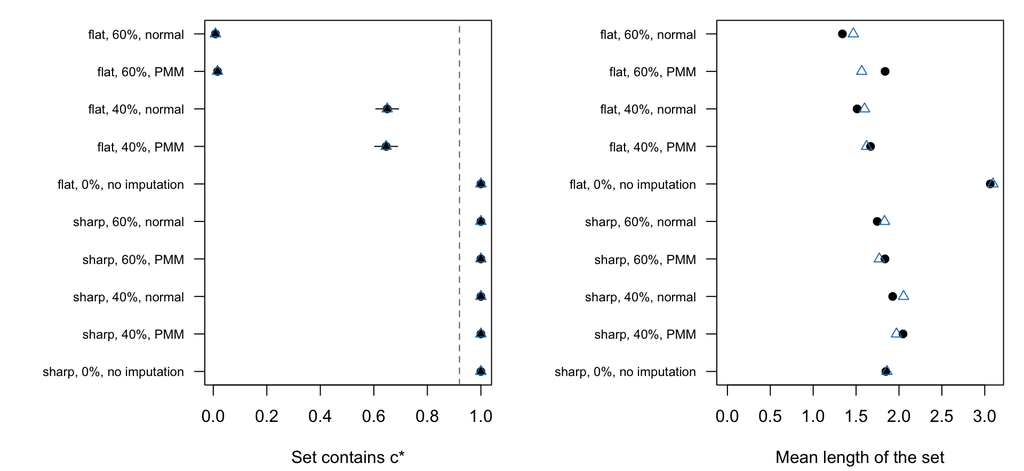

Figure 5: Part A: the near-optimal sets in every cell. Left: share of replicates in which the set contains c* (black: from the bootstrap-then-impute band, with plus and minus two MCSE; blue: from the Rubin’s-rules band), 0.92 dashed. Right: mean length of the set. From results/cell_summaries.rds.

## The optimism and its correction

**Figure guide (part B, every cell).** An unbiased index sits on the zero line. One pair of points is one cell: the mean optimism of the reported index (open circles) and the mean bias of the corrected index (filled), both against the true accuracy of the chosen cutoff, with plus and minus two MCSE. The dashed line is the pre-registered size of 0.01. Look for: how far the open circles sit above zero; whether the filled points sit near zero, and in which cells they overshoot below it.

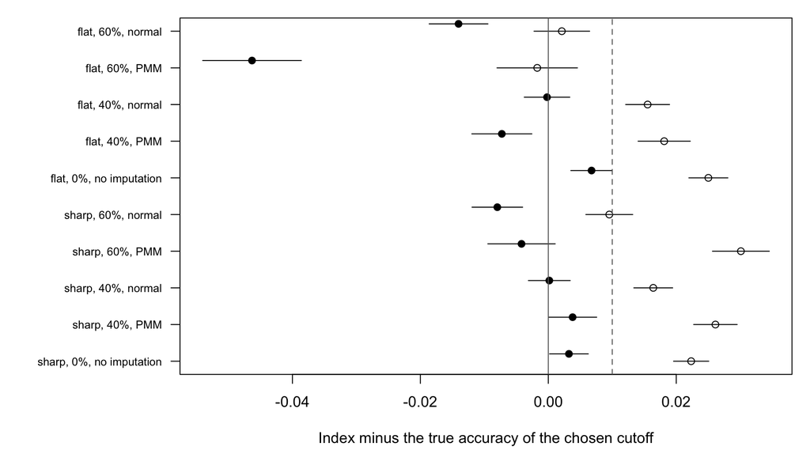

Figure 6: Part B: mean optimism of the reported index (open) and mean bias of the bootstrap-corrected index (filled), both against the true accuracy of the chosen cutoff, with plus and minus two MCSE, in every cell. Solid line 0; dashed line 0.01. From results/cell_summaries.rds.

**Figure guide (base cell and its normal twin, replicate by replicate).** If the bootstrap estimates the optimism well, replicates with more optimism get a larger correction. One point is one replicate: the reported index’s optimism against the correction the bootstrap subtracted, with the identity line dashed. Look for: whether the points rise with the optimism or form a flat cloud; where most points sit relative to the line.

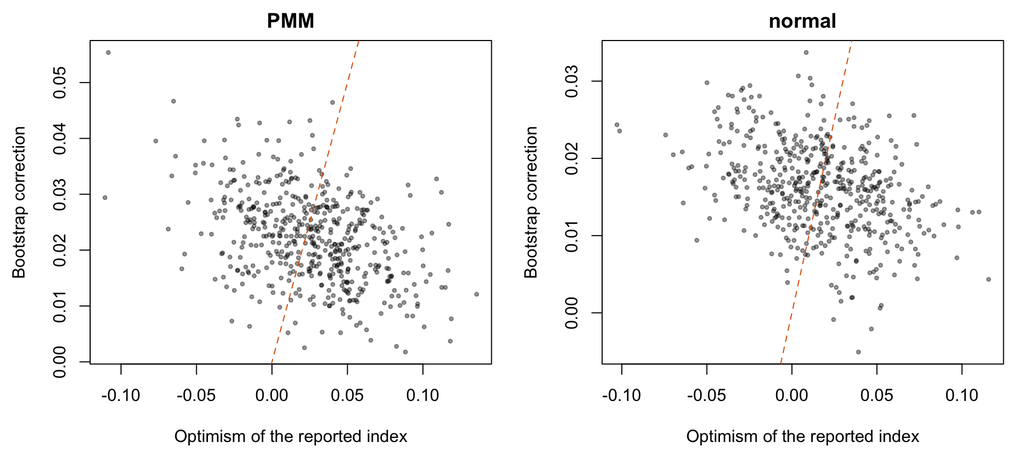

Figure 7: Base cell (sharp, 40% missing, 250 per group) with predictive mean matching (left) and normal imputation (right), all 500 replicates each: the reported index’s optimism against the bootstrap correction, identity line dashed. From results/base_cell_points.rds.

## Numbered findings

Each finding is a claim followed by the output behind it. Read the claim, open the output, and check that you can see the claim there before accepting it. A claim that cannot be seen in the output is a question to raise with the user.

1. **The reported index overstates the chosen cutoff’s accuracy, with or without imputation.** The optimism is 0.0261 (MCSE 0.0017) in the base cell and 0.0223 (MCSE 0.0014) with nothing missing; it is 0.0164 with normal imputation (Figure 6; Table 4).
2. **Pointwise intervals read across thresholds do not cover the curve.** They contain the true curve at all 41 thresholds in 0.35 to 0.80 of replicates across cells, 0.414 in the base cell (Figure 4).
3. **The bootstrap-then-impute correction removes most of the optimism on average where the imputations are unbiased and missing values are not dominant.** The corrected bias is 0.0038 (MCSE 0.0019) in the base cell, 0.0002 (MCSE 0.0016) in its normal twin, and 0.0032 (MCSE 0.0015) without imputation (Figure 6).
4. **The correction does not track a study’s own optimism.** Across the base cell’s replicates the correlation between the reported index’s optimism and the bootstrap correction is -0.42 with predictive mean matching and -0.37 with normal imputation: the correction varies little from study to study and, if anything, is larger where the optimism is smaller, so it fixes the average and not each study’s error (Figure 7).
5. **At 60% missing the correction overshoots.** The corrected bias runs from -0.046 to -0.004 in the 60% cells. In the flat cell with predictive mean matching the reported index’s optimism is -0.0017 (MCSE 0.0031), because the imputations bias the curve downward, and the correction still subtracts 0.045 (Figure 6; Table 4).
6. **The bootstrap-then-impute band covers slightly less than 95% of replicates in every cell, even without imputation.** Its coverage runs from 0.910 to 0.944; in the null cells it is 0.922 and 0.938, and in the base cell 0.910 (MCSE 0.013), below the 0.92 limit within its MCSE (Figure 4; Table 3).
7. **The Rubin’s-rules sup-t band covers without imputation and with the normal engine, and undercovers with predictive mean matching.** Its coverage is 0.936 and 0.954 in the null cells, 0.970 to 0.984 with normal imputation, and 0.744 to 0.906 with predictive mean matching, where the bootstrap band holds (Figure 4; Table 4).
8. **The near-optimal set contains $c^*$ whenever the grid does, and it is wide.** For the sharp shape both sets contain $c^*$ in every replicate of every cell, and their mean length is 1.75 to 2.05 units of a grid about three units wide (Figure 5).
9. **For the flat shape the grid built from observed values often stops short of $c^*$.** The share of replicates whose grid contains $c^*$ is 0.646 at 40% and 0.016 at 60% missing, and the sets’ coverage of $c^*$ equals it (Figure 5; Table 4).
10. **The pooling-order result of the first pilot reproduces.** In the base cell the gap is 0.0029 (MCSE 0.0001) against 0.0028 in the first pilot, and the ratio of root mean squared errors of the cutoff, optimize first over pool first, is 0.79 (MCSE 0.02) against 0.80 (Table 4; the first pilot’s report for the full grid).

## Tables

**Table guide (the verdict).** One row is one criterion of the pre-registered pass rule: the cell it is judged in, the measure, its estimate with its MCSE, the threshold, whether it is met, and whether the estimate lies within three MCSE of the threshold (near). Which criteria decide each answer, and are any of the deciding ones near their thresholds?

Table 3: The re-pilot’s pass rule applied (pilot-b/verdict.R, results/verdict.rds): every criterion of the pre-registration, its estimate and MCSE, its threshold, and whether it is met or near (within three MCSE of the threshold).

| Question | Clause | Cell | Measure | Estimate | MCSE | Threshold | Met | Near |
| --- | --- | --- | --- | --- | --- | --- | --- | --- |
| Q1 | a | base (sharp, 40%, 250, PMM) | optimism of the apparent index | 0.0261 | 0.0017 | > 3 MCSE | yes |  |
| Q1 | b | base (sharp, 40%, 250, PMM) | simultaneous coverage of pointwise intervals | 0.4140 | 0.0220 | < 0.90 | yes |  |
| Q2 | a | base (sharp, 40%, 250, PMM) | optimism of the apparent index | 0.0261 | 0.0017 | >= 0.01 | yes |  |
| Q2 | a | 60% (sharp, 250, PMM) | optimism of the apparent index | 0.0301 | 0.0022 | >= 0.01 | yes |  |
| Q3 | a | base (sharp, 40%, 250, PMM) | \|corrected bias\| / \|apparent optimism\| | 0.1456 | 0.0628 | <= 0.5 | yes |  |
| Q3 | b | base (sharp, 40%, 250, PMM) | simultaneous coverage, bootstrap band | 0.9100 | 0.0128 | in [0.92, 0.98] | no | near |
| Q3 | c | base (sharp, 40%, 250, PMM) | near-optimal set contains c*, bootstrap band | 1.0000 | 0.0000 | >= 0.92 | yes |  |
| Q3 | b | normal twin (sharp, 40%, 250, normal) | simultaneous coverage, bootstrap band | 0.9440 | 0.0103 | in [0.92, 0.98] | yes | near |
| Q3 | c | normal twin (sharp, 40%, 250, normal) | near-optimal set contains c*, bootstrap band | 1.0000 | 0.0000 | >= 0.92 | yes |  |

**Table guide (every cell).** One row is one cell. The first block is the index: the optimism of the reported index and the corrected index’s bias, both against the true accuracy of the chosen cutoff, and the bootstrap’s mean correction. The second block is the curve: the simultaneous coverage of the three bands and the bands’ mean half-widths. The third is the near-optimal sets and the grid: set coverage and length for both sup-t bands, and the share of replicates whose grid contains $c^*$. Where does the corrected bias change sign, and where does the grid stop short of $c^*$?

Table 4: Every cell of the re-pilot: optimism and corrected bias of the index (MCSE), mean bootstrap correction; simultaneous coverage (MCSE) and mean half-width of the pointwise, Rubin’s-rules, and bootstrap-then-impute bands; coverage of c* and mean length of the two near-optimal sets; share of replicates with c* inside the grid; for the closed-form note, the pooling-order gap and the RMSE ratio of the cutoff, optimize first over pool first. From results/cell_summaries.rds.

| Cell | Optimism | Corrected bias | Correction | Pointwise | Rubin band | Bootstrap band | Half-widths | Set, Rubin | Set, bootstrap | c* in grid | Gap | RMSE ratio |
| --- | --- | --- | --- | --- | --- | --- | --- | --- | --- | --- | --- | --- |
| sharp, 0%, no imputation | 0.0223 (MCSE 0.0014) | 0.0032 (MCSE 0.0015) | 0.0161 | 0.560 (MCSE 0.022) | 0.936 (MCSE 0.011) | 0.922 (MCSE 0.012) | 0.062 / 0.093 / 0.092 | 1.000; 1.86 | 1.000; 1.85 | 1.000 | 0.0000 | 1.00 |
| sharp, 40%, PMM | 0.0261 (MCSE 0.0017) | 0.0038 (MCSE 0.0019) | 0.0221 | 0.414 (MCSE 0.022) | 0.868 (MCSE 0.015) | 0.910 (MCSE 0.013) | 0.071 / 0.105 / 0.113 | 1.000; 1.97 | 1.000; 2.05 | 1.000 | 0.0029 | 0.79 |
| sharp, 40%, normal | 0.0164 (MCSE 0.0015) | 0.0002 (MCSE 0.0016) | 0.0160 | 0.734 (MCSE 0.020) | 0.972 (MCSE 0.007) | 0.944 (MCSE 0.010) | 0.072 / 0.106 / 0.095 | 1.000; 2.05 | 1.000; 1.93 | 1.000 | 0.0042 | 0.76 |
| sharp, 60%, PMM | 0.0301 (MCSE 0.0022) | -0.0042 (MCSE 0.0026) | 0.0342 | 0.352 (MCSE 0.021) | 0.744 (MCSE 0.020) | 0.926 (MCSE 0.012) | 0.079 / 0.114 / 0.139 | 1.000; 1.77 | 1.000; 1.84 | 1.000 | 0.0049 | 0.83 |
| sharp, 60%, normal | 0.0095 (MCSE 0.0018) | -0.0080 (MCSE 0.0020) | 0.0173 | 0.770 (MCSE 0.019) | 0.982 (MCSE 0.006) | 0.940 (MCSE 0.011) | 0.080 / 0.116 / 0.102 | 1.000; 1.83 | 1.000; 1.75 | 1.000 | 0.0088 | 0.76 |
| flat, 0%, no imputation | 0.0250 (MCSE 0.0015) | 0.0068 (MCSE 0.0016) | 0.0156 | 0.612 (MCSE 0.022) | 0.954 (MCSE 0.009) | 0.938 (MCSE 0.011) | 0.068 / 0.099 / 0.098 | 1.000; 3.10 | 1.000; 3.06 | 1.000 | 0.0000 | 1.00 |
| flat, 40%, PMM | 0.0181 (MCSE 0.0020) | -0.0073 (MCSE 0.0023) | 0.0252 | 0.572 (MCSE 0.022) | 0.906 (MCSE 0.013) | 0.942 (MCSE 0.010) | 0.077 / 0.111 / 0.117 | 0.646; 1.62 | 0.646; 1.67 | 0.646 | 0.0031 | 0.85 |
| flat, 40%, normal | 0.0155 (MCSE 0.0017) | -0.0002 (MCSE 0.0018) | 0.0155 | 0.718 (MCSE 0.020) | 0.970 (MCSE 0.008) | 0.926 (MCSE 0.012) | 0.077 / 0.111 / 0.102 | 0.650; 1.60 | 0.650; 1.51 | 0.650 | 0.0060 | 0.76 |
| flat, 60%, PMM | -0.0017 (MCSE 0.0031) | -0.0463 (MCSE 0.0039) | 0.0445 | 0.454 (MCSE 0.022) | 0.754 (MCSE 0.019) | 0.932 (MCSE 0.011) | 0.081 / 0.116 / 0.141 | 0.016; 1.57 | 0.016; 1.84 | 0.016 | 0.0037 | 0.88 |
| flat, 60%, normal | 0.0021 (MCSE 0.0022) | -0.0140 (MCSE 0.0023) | 0.0159 | 0.802 (MCSE 0.018) | 0.984 (MCSE 0.006) | 0.934 (MCSE 0.011) | 0.082 / 0.117 / 0.102 | 0.008; 1.47 | 0.008; 1.34 | 0.008 | 0.0106 | 0.74 |

**Table guide (the numbers in the spec).** One row is one number that section 3 of the spec quotes, recomputed here from the result files. Does every number in the spec match its row?

Table 5: Every number quoted in section 3 of project-spec.md, recomputed from results/verdict.rds.

| Item | Cell | Measure | Value | MCSE |
| --- | --- | --- | --- | --- |
| Q1a | base (sharp, 40%, 250, PMM) | optimism of the apparent index | 0.0261 | 0.00170 |
| Q1b | base (sharp, 40%, 250, PMM) | simultaneous coverage of pointwise intervals | 0.4140 | 0.02203 |
| Q2a | base (sharp, 40%, 250, PMM) | optimism of the apparent index | 0.0261 | 0.00170 |
| Q2a | 60% (sharp, 250, PMM) | optimism of the apparent index | 0.0301 | 0.00222 |
| Q3a | base (sharp, 40%, 250, PMM) | \|corrected bias\| / \|apparent optimism\| | 0.1456 | 0.06279 |
| Q3b | base (sharp, 40%, 250, PMM) | simultaneous coverage, bootstrap band | 0.9100 | 0.01280 |
| Q3c | base (sharp, 40%, 250, PMM) | near-optimal set contains c*, bootstrap band | 1.0000 | 0.00000 |
| Q3b | normal twin (sharp, 40%, 250, normal) | simultaneous coverage, bootstrap band | 0.9440 | 0.01028 |
| Q3c | normal twin (sharp, 40%, 250, normal) | near-optimal set contains c*, bootstrap band | 1.0000 | 0.00000 |

# The draft spec

This is `project-spec.md`, read from the file when the document renders. It is the spec of the re-scoped proposal, a conditional draft[^12]. Anything the agent[^13] left for the user to decide is highlighted in yellow and starts with “To confirm”.

| Proposal | `proposal.md`, final 2026-10-28, re-scoped 2026-10-29 (section 12) |
| --- | --- |
| Authors | as in `DESCRIPTION` |
| Written | 2026-10-28; rewritten for the re-scope 2026-10-29 |
| Status | draft 2026-10-28 |

## 1. Question and why it matters

**Question (one sentence):** When a biomarker is missing at random and multiply imputed, do a simultaneous band for the pooled Youden curve, the set of thresholds the band cannot separate from the best one, and a bootstrap-then-impute correction of the reported index give the curve’s uncertainty at the nominal rate and an index that does not overstate the accuracy of the chosen cutoff?

**Why it matters:** An analyst who imputes a missing marker and reports an optimal cutoff reports an index that overstates the cutoff’s accuracy, by about two points of the Youden index at 250 per group in the first pilot, and no interval for the curve or the cutoff, because no method for either exists under imputation. If the procedure works, the analyst reports the pooled curve with its band, the near-optimal thresholds, and a corrected index; the order of pooling, which the first pilot showed changes the index by less than half a point, becomes a closed-form note.

## 2. Mechanism we suspect

The reported index is the maximum of a noisy curve, so it sits above the true accuracy of the threshold it picks: the maximum rewards the threshold where sampling noise happened to push the curve up. With $J(c) = F_0(c) - F_1(c)$, the pooled curve $\bar J$ of $L$ completed datasets, its maximizer $\hat c$, and its maximum $\max_c \bar J(c)$, the optimism is $\max_c \bar J(c) - J(\hat c) \ge 0$ in expectation; it is present without any missing data (Fluss, Faraggi, and Reiser 2005 report the empirical method’s poor performance) and imputation adds the pooling-order gap $\kappa \hat B_c / 2$ on top of it for an analyst who optimizes first. A bootstrap that repeats the whole analysis, imputation included, estimates that optimism if the resample’s maximum relates to the original curve as the original maximum relates to $J$; for a cube-root estimator the standard bootstrap is inconsistent (Cattaneo, Jansson, and Nagasawa 2020), so the correction may remove only part of it. For the curve itself, $\bar J(c)$ at a fixed $c$ is an average of differences of proportions, regular, so a band built from Rubin’s rules (the binomial covariance of the empirical curve within imputations plus the covariance of the curves between imputations) or from bootstrap-then-impute should cover $J$ over a range of thresholds at the nominal rate when the imputations are proper and unbiased. When the imputations are biased, as predictive mean matching was where donors are sparse in the first pilot, no variance method restores coverage, which is why the correctly specified normal imputation is in the design. If the band covers, the near-optimal set $\{c : U(c) \ge \max_{c'} L(c')\}$ contains $c^*$, because $U(c^*) \ge J^* \ge J(c') \ge L(c')$ for every $c'$.

## 3. Pilot

Filled twice: the plan when the spec is written, the answers after the verdict (stage 2, step 5). The first pilot (`pilot/`, `piloted-fail`) and its answers are in `pilot/pilot-report.html`; this section is the re-pilot’s.

**Code:** `pilot-b/pilot.R`, run from the project root with `Rscript pilot-b/pilot.R`; it calls the functions in `R/` (the first pilot’s, plus the curve on a grid, the two bands, the near-optimal set, the optimism correction, and the normal imputation). `pilot-b/verdict.R` applies the pass rule to the saved summaries.

**Pass rule:** from `proposal.md`, section 12, made exact in `pilot-b/preregistration.md`. The base cell is the sharp symmetric peak, 40% missing, 250 per group, predictive mean matching, $L = 20$, the empirical estimator.

1. The problem exists if, in the base cell, the apparent index exceeds the true accuracy of the chosen cutoff by more than three Monte Carlo standard errors, and the pointwise Rubin’s intervals read as a band cover $J$ over the grid in less than 0.90 of replicates.
2. It is large enough if the apparent index’s optimism is at least 0.01 in the base cell or in its 60% twin.
3. There is a fix if (a) the corrected index’s absolute bias against the true accuracy of the chosen cutoff is at most half the apparent index’s in the base cell; (b) the bootstrap-then-impute band covers $J$ over the grid in 0.92 to 0.98 of the base cell’s replicates for both engines; and (c) its near-optimal set contains $c^*$ in at least 0.92 of the base cell’s replicates for both engines.

**Verdict file:** `pilot-b/results/verdict.rds` (with `pilot-b/results/verdict.csv`), written by `pilot-b/verdict.R` after the run.

**Plot:** `pilot-b/results/coverage-by-cell.png`, the simultaneous coverage of each band in every cell, written by `pilot-b/verdict.R`.

**The three pilot answers:** status `piloted-close-call`, by the pre-registered rule, from `pilot-b/results/verdict.rds`; 500 replicates per cell, run label `pilot`.

1. Does the effect exist? Yes. In the base cell the reported index exceeds the true accuracy of the chosen cutoff by 0.0261 (MCSE 0.0017), and the pointwise Rubin’s intervals read as a band contain the true curve at all 41 thresholds in 0.414 (MCSE 0.022) of replicates.
2. Is it large enough to matter at realistic sample sizes? Yes: the optimism is 0.0261 in the base cell and 0.0301 (MCSE 0.0022) with 60% missing, above 0.01.
3. Is there an obvious fix or diagnostic? Partly. The bootstrap-then-impute correction leaves a bias of 0.15 (MCSE 0.06) of the optimism in the base cell, and its near-optimal set contains $c^*$ in 1.000 of replicates with both engines. The bootstrap-then-impute band covers in 0.910 (MCSE 0.013) of replicates with predictive mean matching, below and near the 0.92 limit, and in 0.944 (MCSE 0.010) with normal imputation.

## 4. ADEMP skeleton

This becomes `protocol.md` at the design stop of stage 3.

**Aims.**

1. Do the Rubin’s-rules and the bootstrap-then-impute bands cover the Youden curve over a range of thresholds at 95%, and does the near-optimal set derived from each contain the optimal cutoff at least as often, across shapes, sizes, missing fractions, and imputation engines?
2. Does the bootstrap-then-impute optimism correction remove the overstatement of the reported index, against the true accuracy of the chosen cutoff and against the maximum of the curve?
3. As a closed-form note: how large is the pooling-order gap against $\kappa B_c / 2$, and is the averaged cutoff more accurate than the pooled argmax? For a discrete covariate (Aim 3 of the proposal), do the procedures recover the stratum-specific and the population-optimal cutoffs?

**Data-generating mechanisms.**

- Factors varied, with levels: the peak shape (sharp symmetric, flat asymmetric, two near-equal maxima); the missing fraction (0%, 20%, 40%, 60%); the sample size per group (100, 250, 1,000); the strength of the auxiliary; the imputation engine (predictive mean matching, normal linear regression, the nearest-neighbour method of Long, Zhang, and Hsu 2011 with several auxiliaries); the within-dataset estimator (empirical, Gaussian kernel); the number of bootstrap resamples and imputations per resample; for Aim 3, two to four strata with the prevalence ratio varied.
- Factors fixed, and why: missingness at random through the auxiliary and the disease status, because the claims are made under that assumption; the disease status always observed (verification bias is a different paper); equal group sizes in the base design, with one unbalanced arm at fixed total size.
- A cell where the answer is known: 0% missing, where the bands are complete-data bands and the pooling-order gap is exactly zero; a noiseless curve, whose optimism is zero; independent grid points, where the sup-t critical value has a closed form.

**Estimands.** The Youden curve $J(c)$ over a range of thresholds; its maximizer $c^*$ and maximum $J^*$; the true accuracy $J(\hat c)$ of a chosen threshold and the regret $J^* - J(\hat c)$; for Aim 3, $c_{\mathrm{cs}}(v)$ and $c_{\mathrm{pop}}(v)$.

**Methods compared.** For the curve: pointwise Rubin’s intervals (the default), the Rubin’s-rules sup-t band, the bootstrap-then-impute sup-t band, and impute-then-bootstrap; the near-optimal set from each band; for the index: the apparent pooled maximum, the bootstrap-then-impute optimism-corrected index, and the complete-data intervals of Bantis, Nakas, and Reiser (2019) on the complete cases; for the cutoff: pool first, optimize then mean, optimize then median, and the bagged cutoff of Zhang et al. (2020).

**Performance measures.** Simultaneous coverage and mean half-width of each band; coverage of $c^*$ by each near-optimal set and its mean length; bias of each index against $J(\hat c)$ and against $J^*$; bias, empirical standard error, and root mean squared error of the cutoff and the regret; the pooling-order gap against its closed form. No method in the design is a hypothesis test, so no power cells are planned; if a test is added, its power cells follow `workflow/rules.md`, section 3.

**Replicates and Monte Carlo SE target.** **To confirm:** 2,000 replicates per cell in the production run, which gives a Monte Carlo standard error of about 0.005 for a coverage near 0.95; idea.md planned 1,000, which gives about 0.007

## 5. Application

**Dataset:** NHANES 2013-2014, 2015-2016, and 2017-2018 pooled: the serum cotinine (`COT_H`, `COT_I`, `COT_J`), smoking questionnaire (`SMQ_H`, `SMQ_I`, `SMQ_J`), and demographics (`DEMO_H`, `DEMO_I`, `DEMO_J`) files from `wwwn.cdc.gov/Nchs/Data/Nhanes/Public/YEAR/DataFiles/` (YEAR 2013, 2015, 2017), downloaded by `analysis/00_download.R` into `data/raw/`. The documentation pages of all three cycles give the same laboratory method (isotope-dilution high-performance liquid chromatography with tandem mass spectrometry) and the same lower limit of detection, 0.015 ng/mL (read 2026-10-28), so the three cycles are pooled with the cycle as an auxiliary.

**Comparison:** adults with a smoking answer, current smokers against everyone else, on the log scale of serum cotinine in ng/mL; race/ethnicity as the discrete covariate of Aim 3; the counts per group and the share with cotinine missing, by cycle, are in `pilot/results/nhanes_summary.rds`.

**What to show:** on adults with observed cotinine and a smoking answer, with missingness imposed at random given age, sex, education, income, cycle, and race/ethnicity at 20 to 60%, the pool-first and optimize-first cutoffs fall inside one near-optimal set while the optimize-first index exceeds the pool-first index by the amount $\kappa \hat B_c / 2$ predicts, with the full-data cutoff as the benchmark; by race/ethnicity, the stratum-specific and population-optimal cutoffs differ in the direction the prevalence ratio sets.

## 6. Target journal

**Target journal:** Statistical Methods in Medical Research: room for three aims and the simulation, the home of the imputation order-of-operations papers, no charge.

**Fallback:** Biometrical Journal: the home of the cutoff-inference papers, the same readers; switching costs moving Aim 3 and the derivations to the supplement to meet 4,500 words and rewriting the abstract; the single-anonymized review lets the repository link stay open.

Target’s limit and AI policy: around 8,000 words; “AI chatbots, for example ChatGPT, should not be listed as authors”; generative use that affects methods, analysis, or results is disclosed at submission in the Methods or Acknowledgements.

## 7. Milestones

**To confirm:** the dates below spread the eight months of idea.md from 2026-10-28; no deadline was given at stage 1

| Stage | Ends with | Due |
| --- | --- | --- |
| 2. Pilot | `pilot/pilot-report.html`, the verdict file, `pilot/decisions.md` | 2026-10-29 |
| 3. Manuscript, design stop | `protocol.md` from the approved design | 2026-12-31 |
| 3. Manuscript, first draft | `manuscript/manuscript.html` in draft mode | 2027-04-30 |
| 3. Manuscript, settled | the draft after the revision rounds | 2027-05-31 |
| 4. Background report | `background/background.html` | 2027-06-11 |
| 5. Mock review | the last `review/round-N/` | 2027-06-25 |
| Submission | the final render and the checker in final mode | 2027-06-30 |

## 8. Out of scope

The project must not add:

- A second application dataset: ADNI and the Pima data were set aside at stage 1.
- A continuous covariate for Aim 3: Aim 3 is restricted to a discrete covariate (stage 1).
- Missing disease status (the verification-bias problem) or missingness not at random: each is its own paper.
- Cutoff criteria other than the Youden index and its population-weighted form of Aim 3: a natural sequel, parked.
- A theory of the bootstrap for cube-root estimators under imputation (for example a subsampling or modified-bootstrap correction in the manner of Cattaneo, Jansson, and Nagasawa 2020): if the re-pilot shows the plain correction falls short, that theory is a separate paper, parked.
- A software paper or a CRAN release: the package `micutoff` is the compendium’s byproduct.
- A reporting checklist for applied users: a separate applied note, parked.

## 9. Reading

1. Bartlett and Hughes 2020. After reading, a reader can answer: why does imputing and then bootstrapping give invalid variances under uncongeniality, and which bootstrap-then-impute variants stay valid?
2. Fluss, Faraggi, and Reiser 2005. After reading, a reader can answer: which complete-data estimator of the Youden index has the worst performance, and in which direction is the empirical index biased?
3. Long, Zhang, and Hsu 2011. After reading, a reader can answer: how are the imputed datasets combined into one ROC curve, and what is reported for the uncertainty of the threshold the paper calls the unanimous optimum?

# Decisions log

This is the agent’s `decisions.md` for the re-pilot, read from the file when the document renders.

Each decision says what was decided, the alternatives, why, what the user should check, and the file that holds its numbers. The first pilot’s decisions are `pilot/decisions.md`; those it relies on (D4, the cutoff’s convention; D7, the exact average; D9, Rubin’s rules for one threshold) carry over unchanged. The pre-registration is `pilot-b/preregistration.md`, with an amendment committed before the run.

## D0. The literature pass

No new literature was read. The re-scope rests on sources already in `manuscript/citations.csv`: Bartlett and Hughes (2020) and von Hippel and Bartlett (2021) for bootstrap-then-impute with few imputations per resample, Cattaneo, Jansson, and Nagasawa (2020) for the inconsistency of the standard bootstrap for cube-root estimators, Fluss, Faraggi, and Reiser (2005) for the empirical maximum’s bias, and Zhang et al. (2020) for the bagged cutoff. Two sources the procedure uses are not in the Zotero library: one for the bootstrap optimism correction, and Rubin (1987) for Rubin’s rules; both are `[CITE]` markers.

## D1. The status call

The status is `piloted-close-call`, by the pre-registered rule (`pilot-b/preregistration.md`, section 5), applied by `pilot-b/verdict.R` (`pilot-b/results/verdict.rds`). Questions 1 and 2 pass clearly. Question 3 passes clauses (a) and (c) and fails clause (b) in the base cell with predictive mean matching, where the bootstrap-then-impute band’s coverage is within three MCSE of its 0.92 limit; a failed question 3 with every failed clause near its threshold is a close call.

The reading that passes: the correction removes most of the optimism in the base cell; the bootstrap band covers between 0.91 and 0.94 in every cell, including the 60% predictive-mean-matching cells where the Rubin’s-rules band falls far below; the base cell’s shortfall from 0.92 is within its Monte Carlo error; with the correctly specified normal imputation the band passes; and every near-optimal set contains $c^*$ whenever the grid does. Aim 1 of the re-scoped proposal holds, and the full design tunes the band.

The reading that fails: the band undercovers in the base cell, and it sits below 0.95 even in the null cells, where nothing is imputed, so the bootstrap sup-t band is slightly liberal at 250 per group for reasons of the bootstrap, not the imputation. The correction fixes the average optimism but does not track a study’s own optimism: across the base cell’s replicates the two are negatively correlated (`pilot-b/results/base_cell_points.rds`). It also overshoots below zero at 60% missing, most of all in the flat cell with predictive mean matching, where the imputations’ own downward bias offsets the optimism and the correction subtracts it again. The near-optimal sets pass clause (c) because they are wide, about two-thirds of the grid, so the clause measures coverage and not usefulness; and for the flat shape the grid built from observed values misses $c^*$ in a third of replicates at 40% missing and nearly all at 60%.

What the user should check: the numbers behind both readings in `pilot-b/results/verdict.csv` and `pilot-b/results/cell_summaries.csv`; whether the set’s width is acceptable; and the decision at the stop (pass, with the band and the grid tuned in the full design; or another revision).

## D2. The re-scope and its pass rule were not reviewed before the run

What: the proposal’s section 12 and the re-pilot’s pass rule were written by the agent and pre-registered without a stop, because the user asked for the re-pilot to follow the revision. Alternatives: a stop on the revised proposal before the re-pilot. Why: the user’s instruction. Check: the three questions and their thresholds (`proposal.md`, section 12; `pilot-b/preregistration.md`, section 5), before reading the verdict as settled.

## D3. The amendment before the run

What: the optimism of a resample is read at each curve’s chosen cutoff, $\bar J_b(\hat c_b) - \bar J(\hat c_b)$, and the corrected index starts from $\bar J(\hat c)$, not from the maximum. Why: the known-answer check of a reproducing bootstrap failed under the first definition, because the tie rule’s cutoff need not attain the maximum when tied intervals lie apart. The amendment was committed before any run; the pass rule is unchanged. Check: the known-answer row in `pilot-b/results/known_answers.rds` and the columns `apparent` and `apparent_at_c_hat` in the replicates.

## D4. The normal imputation engine

What: Bayesian normal linear regression (`mice::mice.impute.norm()`) with $D$, $Z$, $D \times Z$, beside predictive mean matching. Alternatives: the nearest-neighbour engine of the first pilot. Why: the normal model is correctly specified for this design, so a band that fails with it fails for reasons of inference, while a band that fails only with predictive mean matching fails because of the imputations; the nearest-neighbour engine with one auxiliary does not propagate the models’ uncertainty (first pilot, D5). Check: the known-answer rows on the normal imputation.

## D5. The grid

What: 41 thresholds between the 10% and 90% quantiles of the observed marker. Alternatives: a fixed range around $c^*$, which an analyst does not know. Why: it is computed from the data an analyst has. Consequence: missing values fall mostly at high marker values, so the grid’s upper end moves down as the missing fraction grows; whether $c^*$ lies inside the grid is recorded per replicate (`c_star_in_grid` in `pilot-b/results/cell_summaries.rds`), and a near-optimal set cannot contain a $c^*$ outside the grid.

## D6. The variance split and the critical value of the bootstrap band

What: the pointwise variance of the 20-imputation estimate is the variance of the resample means minus the within-resample imputation variance over $M$ plus the same over $L$, floored at zero; the critical value standardizes each resample’s deviation by the resample means’ own standard deviation. Alternatives: no split (the band too wide by the imputation noise of $M = 2$); a critical value from the split standard errors. Why: the split targets the estimate actually reported, and the critical value uses the spread the resamples have. Check: the band’s coverage in the null cells, where the split has nothing to remove.

## D7. The replicate count

What: 500 replicates per cell, as pre-registered; the timing run projected 7 minutes on three workers (`pilot-b/results/timing.rds`), far inside the hour. Alternatives: more replicates, which the pre-registration did not provide for. Check: the actual runtime in `pilot-b/results/run_info.rds`.

## What was not done

- The kernel estimator, 1,000 per group, impute-then-bootstrap, the nearest-neighbour engine, the number of resamples and imputations per resample as factors, and the application: all left to the full design (`project-spec.md`, section 4).
- A grid that does not depend on the observed values, which the flat cells show is needed.
- A target for the near-optimal set’s length: the pass rule judged only whether the set contains $c^*$.
- More replicates: the run took 9 minutes, and the pre-registration fixed 500, so the base cell’s coverage is judged with an MCSE of about 0.013.

# Action items and limitations

## Action items

1. **Decide the status.** The rule gives `piloted-close-call`. Read as a pass, Aim 1 of the re-scoped proposal holds and stage 3 starts, with the band’s calibration and the grid as design questions; read as a fail, the proposal is revised again for a re-pilot in `pilot-c/`. Both readings are in the decisions log (D1).
2. **Review the re-scope and the re-pilot’s pass rule** (`proposal.md`, section 12; `preregistration.md`, section 5 and its amendment), which were written and pre-registered without a stop at your instruction (D2, D3).
3. **Decide whether the near-optimal set’s width matters.** The rule judged only whether the set contains $c^*$; a set spanning two-thirds of the grid is valid and says little.
4. **Resolve the yellow `[TO CONFIRM]` items** in the spec: the production replicate count, and the milestone dates.
5. **Verify the citations written from memory:** Rubin (1987), named in a footnote, and a source for the bootstrap optimism correction, both marked as not in the Zotero library.
6. **Choose the grid for the full design.** A grid from observed quantiles misses $c^*$ when missing values sit at high marker values; a grid from the imputed values or a fixed range removes that.

## Limitations

- The re-pilot covers two binormal shapes at 250 per group, one auxiliary, missingness at random, the empirical estimator, and 200 resamples with 2 imputations each; none of these was varied.
- With 500 replicates the MCSE of a coverage near 0.95 is about 0.01, so the base cell’s coverage of 0.910 cannot be told apart from 0.92 or from 0.90.
- The normal imputation is correctly specified only because the design makes the marker and the auxiliary jointly normal; real imputation models are misspecified to some degree.
- The optimism correction was judged against the true accuracy of the chosen cutoff; against $J^*$ the corrected index is biased downward, by -0.077 to 0.001 across cells, as the regret of the chosen cutoff implies.
- The application was not analysed; its description is the first pilot’s.

## Footnotes

[^1]: A pilot is a quick, small first run of the proposal’s simulation, done before the project goes further, to check that the idea is worth the time. It asks three questions: does the effect exist, is it large enough at realistic sample sizes, and is there an obvious fix or diagnostic? The proposal (`proposal.md`) holds the pilot plan and its pass criteria.
[^2]: `piloted-pass` means all three pilot questions got a clear yes. `piloted-fail` means at least one clearly did not, so the project should not go on as proposed. `piloted-close-call` means at least one answer could be read either way, so the call is stated both ways: the reading that passes and the reading that fails.
[^3]: A draft that applies only if the proposal is re-scoped as described. If the proposal stays as written, it is a record only.
[^4]: The Youden index of a threshold is sensitivity plus specificity minus one: the share of diseased people the threshold flags minus the share of healthy people it flags. Its maximum over thresholds, and the threshold that attains it, are the usual “optimal cutoff”.
[^5]: Multiple imputation fills each missing value several times with draws from a model of the missing value given what is observed, analyses each completed dataset, and combines the analyses.
[^6]: The bootstrap redraws the study’s subjects with replacement to make new datasets of the same size, reruns the whole analysis on each, and uses the spread of the results to measure the uncertainty of the original one. Here each redrawn dataset is also re-imputed, the order Bartlett and Hughes (2020) found valid when the imputation model and the analysis do not match.
[^7]: The National Health and Nutrition Examination Survey, run by the United States National Center for Health Statistics, combines interviews with physical examinations and laboratory tests on a sample of the population, released as public files every two years.
[^8]: Cotinine is the main product of nicotine in the body and stays in the blood for days, so its level in serum separates people who smoke from people who do not, and its low range measures exposure to other people’s smoke.
[^9]: Here a current smoker is an adult who has smoked at least 100 cigarettes in life and now smokes every day or some days; every other adult who answered is counted as a nonsmoker.
[^10]: Predictive mean matching fits a regression of the marker on the other variables, and for each missing value takes the observed value of a randomly chosen donor among the few observed subjects whose predicted values are closest; here through the R package `mice`, with 5 donors.
[^11]: Bayesian normal linear regression imputation draws the regression’s coefficients and residual variance from their posterior distribution, then draws each missing value from the normal distribution they imply; here through the R package `mice`. With one auxiliary that is jointly normal with the marker within each group, it is the correct model for this design.
[^12]: A draft that applies only if the proposal is re-scoped as described. If the proposal stays as written, it is a record only.
[^13]: The AI agent that ran the pilot, wrote the files this document is built from, and kept a log of its decisions.